# Assignment 3 - Model Selection & Non-linearity

Ziwen Zhang

2023-06-28

# Model Selection

The goal of this assignment is to use real and messy data to build a predictive model for heart disease. The data correspond to a study that was conducted in four centers and therefore there are four sources of the data - from Cleveland, Switzerland, Long Beach V. A. and Hungary.

The main outcome is presence of heart disease in the patient. It is integer valued from 0 (no presence) to 4. Convert this into a binary outcome - absence (0) vs presence (1,2,3,4) of heart disease.

Predictors: There are 76 attributes/predictors of this database, 14 of them have been used before and there are available in a clean format. File having “processed” in their name are clean files with 14 predictors.

## Question 1 (a) Data Wrangling

```r
library(readr)
library(tidyverse)
# load four processed data sets
cleveland <- read.csv("processed.cleveland.data", header = FALSE)
hungarian <- read.csv("processed.hungarian.data", header = FALSE)
switzerland <- read.csv("processed.switzerland.data", header = FALSE)
longbeachva <- read.csv("processed.va.data", header = FALSE)

# change data type
cleveland <- cleveland %>%
  mutate_all(as.numeric)
## str(cleveland)

hungarian <- hungarian %>%
  mutate_all(as.numeric)
## str(hungarian)

switzerland <- switzerland %>%
  mutate_all(as.numeric)
## str(switzerland)

longbeachva <- longbeachva %>%
  mutate_all(as.numeric)
## str(longbeachva)

# combine into final data
data <- bind_rows(cleveland, hungarian, switzerland, longbeachva)

# rename the column names
column_names <- c("age", "sex", "chest_pain", "rest_blood_pressure", "cholesterol", "fasting_blood_sugar", "rest_ecg", "max_heart_rate", "exercise_angina", "oldpeak", "slope", "vessels", "thal", "target")
colnames(data) <- column_names

# check missing value in the final data set
colSums(is.na(data))
```

```
##                 age                 sex          chest_pain rest_blood_pressure
##                   0                   0                   0                  59
##         cholesterol fasting_blood_sugar            rest_ecg      max_heart_rate
##                  30                  90                   2                  55
##     exercise_angina             oldpeak               slope             vessels
##                  55                  62                 309                 611
##                thal              target
##                 486                   0
```

```r
# remove missing values
data <- data %>%
  select(-"slope", -"vessels", -"thal") %>%
  na.omit()

# convert the outcome into binary outcome - absence (0) and presence (1)
data$target <- ifelse(data$target == 0, 0, 1)

n <- nrow(data)
p <- ncol(data) - 1
paste("The final sample size (n) is ", n)
```

```
## [1] "The final sample size (n) is  740"
```

```r
paste("The number of predictors (p) is ", p)
```

```
## [1] "The number of predictors (p) is  10"
```

There are 740 observations and 10 variables in the final data set. I firstly check the missing value for each variable in the final data set and find that the missing values are concentrated at the variable 11 (“slope”), variable 12 (“vessels”), and variable 13 (“thal”). In order to keep as many observations as possible and make sure that data are balanced among the four sources, I removed these three column before removing rows contain missing value.

## Question 1 (b) Bonus

```r
raw_cleveland <- read.csv("cleveland.data", header = FALSE)
raw_hungarian <- read.csv("hungarian.data", header = FALSE)
raw_switzerland<- read.csv("switzerland.data", header = FALSE)
raw_longbeachva <- read.csv("long-beach-va.data", header = FALSE)
```

## Question 2

The goal is to find the best regression-based model for “predicting” heart disease. The best model should be based on each of the following three methods - a) Best subset selection (hint: learn to use package R/bestglm). b) Stepwise regression (choose one - forward, backward or both direction) c) Elastic Net regression (choose an appropriate value of and explain the reasons for that choice).

### (a) Best subset selection

(hint: learn to use package R/bestglm)

```r
library(bestglm)
set.seed(234)
# divide data into testing and training 50%
test_index = sample(nrow(data), ceiling(0.5*nrow(data)))
test_data <- data[test_index, -ncol(data)]
train_data <- data[-test_index, ]

test_label <- as.numeric(data[test_index, ncol(data)])
test_full <- data[test_index, ]

# fit best subset selection model
regfit.bss <- bestglm(train_data, family = binomial, IC = "AIC")
```

```
## Morgan-Tatar search since family is non-gaussian.
```

```r
summary(regfit.bss$BestModel)
```

```
##
## Call:
## glm(formula = y ~ ., family = family, data = Xi, weights = weights)
##
## Deviance Residuals:
##     Min       1Q   Median       3Q      Max
## -2.7529  -0.6584   0.1759   0.6211   2.2576
##
## Coefficients:
##                      Estimate Std. Error z value Pr(>|z|)
## (Intercept)         -1.429818   1.649998  -0.867  0.38618
## age                  0.026148   0.017696   1.478  0.13950
## sex                  1.020373   0.333952   3.055  0.00225 **
## chest_pain           0.382582   0.158786   2.409  0.01598 *
## cholesterol         -0.004163   0.001682  -2.474  0.01334 *
## fasting_blood_sugar  0.751671   0.378531   1.986  0.04706 *
## rest_ecg             0.261413   0.174447   1.499  0.13400
## max_heart_rate      -0.016283   0.006224  -2.616  0.00890 **
## exercise_angina      1.424788   0.334834   4.255 2.09e-05 ***
## oldpeak              0.810993   0.173856   4.665 3.09e-06 ***
## ---
## Signif. codes:  0 '***' 0.001 '**' 0.01 '*' 0.05 '.' 0.1 ' ' 1
##
## (Dispersion parameter for binomial family taken to be 1)
##
##     Null deviance: 511.10  on 369  degrees of freedom
## Residual deviance: 317.97  on 360  degrees of freedom
## AIC: 337.97
##
## Number of Fisher Scoring iterations: 5
```

```r
# make predictions on testing data and calculate mean standard error
pred_label_bss <- ifelse(predict(regfit.bss$BestModel, newdata = test_data, type = "response") > 0.5, 1, 0)

library(ModelMetrics)
mse_bss <- mse(test_label, pred_label_bss)
mse_bss
```

```
## [1] 0.2054054
```

The MSE of the best model selected is 0.2054

### (b) stepwise selection

(choose one - forward, backward or both direction)

```r
# fit a stepwise regression model
model <- glm(target ~ ., data = train_data, family = "binomial")
regfit.fwd <- step(model, direction = "forward", trace = F)
summary(regfit.fwd)
```

```
##
## Call:
## glm(formula = target ~ age + sex + chest_pain + rest_blood_pressure +
##     cholesterol + fasting_blood_sugar + rest_ecg + max_heart_rate +
##     exercise_angina + oldpeak, family = "binomial", data = train_data)
##
## Deviance Residuals:
##     Min       1Q   Median       3Q      Max
## -2.7514  -0.6578   0.1765   0.6201   2.2572
##
## Coefficients:
##                      Estimate Std. Error z value Pr(>|z|)
## (Intercept)         -1.392957   1.931024  -0.721  0.47069
## age                  0.026235   0.017857   1.469  0.14178
## sex                  1.019960   0.334087   3.053  0.00227 **
## chest_pain           0.381708   0.160567   2.377  0.01744 *
## rest_blood_pressure -0.000278   0.007567  -0.037  0.97070
## cholesterol         -0.004161   0.001683  -2.473  0.01340 *
## fasting_blood_sugar  0.752301   0.378920   1.985  0.04710 *
## rest_ecg             0.261687   0.174624   1.499  0.13398
## max_heart_rate      -0.016304   0.006252  -2.608  0.00912 **
## exercise_angina      1.427150   0.340990   4.185 2.85e-05 ***
## oldpeak              0.810880   0.173857   4.664 3.10e-06 ***
## ---
## Signif. codes:  0 '***' 0.001 '**' 0.01 '*' 0.05 '.' 0.1 ' ' 1
##
## (Dispersion parameter for binomial family taken to be 1)
##
##     Null deviance: 511.10  on 369  degrees of freedom
## Residual deviance: 317.97  on 359  degrees of freedom
## AIC: 339.97
##
## Number of Fisher Scoring iterations: 5
```

```r
# make predictions on testing data and calculate mean standard error
pred_label_fwd <- ifelse(predict(regfit.fwd, newdata = test_data, type = "response") > 0.5, 1, 0)

mse_fwd <- mse(test_label, pred_label_fwd)
mse_fwd
```

```
## [1] 0.2054054
```

The MSE of the forward stepwise model is 0.2054

### (c) elastic net regression

(choose an appropriate value of alpha and explain the reasons for that choice)

```r
set.seed(345)
library(glmnet)
# separate the predictors and label
x <- model.matrix(target ~., train_data)[,-1] # remove the first column corresponding to the intercept
y <- train_data$target

# Lasso Regression
lambda_lasso <- cv.glmnet(x, y, family = "binomial", nfolds = 10, alpha = 1)
regfit.lasso <- glmnet(x, y, family = "binomial", alpha = 1, lambda = lambda_lasso$lambda.min)
coef(regfit.lasso)
```

```
## 11 x 1 sparse Matrix of class "dgCMatrix"
##                               s0
## (Intercept)         -1.364847306
## age                  0.024936141
## sex                  0.944896596
## chest_pain           0.359102590
## rest_blood_pressure  .
## cholesterol         -0.003585197
## fasting_blood_sugar  0.636056557
## rest_ecg             0.201325709
## max_heart_rate      -0.015383605
## exercise_angina      1.340721972
## oldpeak              0.747843863
```

```r
# Ridge Regression
lambda_ridge <- cv.glmnet(x, y, family = "binomial", nfolds = 10, alpha = 0)
regfit.ridge <- glmnet(x, y, family = "binomial", alpha = 0, lambda = lambda_ridge$lambda.min)
coef(regfit.ridge)
```

```
## 11 x 1 sparse Matrix of class "dgCMatrix"
##                                s0
## (Intercept)         -1.6012128077
## age                  0.0265503317
## sex                  0.8848036436
## chest_pain           0.3664183404
## rest_blood_pressure  0.0008632105
## cholesterol         -0.0032731683
## fasting_blood_sugar  0.6053915285
## rest_ecg             0.1936320389
## max_heart_rate      -0.0146219775
## exercise_angina      1.2213290588
## oldpeak              0.6390657601
```

```r
# Elastic Net Regression
lambda_elastic_net <-  cv.glmnet(x, y, family = "binomial", nfolds = 10, alpha = 0.5)
regfit.net <- glmnet(x, y, family = "binomial", alpha = 0.5, lambda = lambda_elastic_net$lambda.min)
coef(regfit.net)
```

```
## 11 x 1 sparse Matrix of class "dgCMatrix"
##                               s0
## (Intercept)         -1.382476752
## age                  0.025052786
## sex                  0.895745112
## chest_pain           0.351663251
## rest_blood_pressure  .
## cholesterol         -0.003249719
## fasting_blood_sugar  0.579557698
## rest_ecg             0.174083366
## max_heart_rate      -0.014790981
## exercise_angina      1.273327839
## oldpeak              0.688724646
```

**Interpretation:** In Elastic Net regression, the alpha parameter controls the balance between the L1 (Lasso) and L2 (Ridge) regularization penalties. It takes values between 0 and 1, where 0 corresponds to Ridge regression and 1 corresponds to Lasso regression. To determine an appropriate alpha value, we can use cross-validation to evaluate different alpha values and select the one that minimized the prediction error.

```r
# separate the test predictors and labels
x_test <- model.matrix(target ~., test_full)[,-1]

# make predictions on testing data and calculate the mean squared error
pred_label_lasso <- ifelse(predict(regfit.lasso, newx = as.matrix(x_test), type = "response") > 0.5, 1, 0)

mse_lasso <- mse(test_label, pred_label_lasso)
mse_lasso
```

```
## [1] 0.2054054
```

```r
pred_label_ridge <- ifelse(predict(regfit.ridge, newx = as.matrix(x_test), type = "response") > 0.5, 1, 0)

mse_ridge <- mse(test_label, pred_label_ridge)
mse_ridge
```

```
## [1] 0.2054054
```

```r
pred_label_net<- ifelse(predict(regfit.net, newx = as.matrix(x_test), type = "response") > 0.5, 1, 0)

mse_net <- mse(test_label, pred_label_net)
mse_net
```

```
## [1] 0.2081081
```

# Non-linearity

Dataset: Use the “Heart” dataset saved in the module that contains a binary outcome AHD for 303 patients who presented with chest pain. An outcome value of Yes indicates the presence of heart disease based on an angiographic test, while No means no heart disease. There are 13 predictors including Age, Sex, Chol (a cholesterol measurement), and other heart and lung function measurements.

## Question 3 (a)

For AHD as a binary outcome, fit a generalized additive model with a smoothing spline for age as predictors. and choose the smoothing parameter by comparing an estimate of in-sample error (e.g. AIC).

Plot the relationship of the predictor with the smoothing spline with the chosen smoothing parameter. Include standard errors in the plot.

Print the summary of the GAM model. Compare the interpretation of your chosen GAM model with that of a logistic regression model with 3rd degree polynomials (including linear, quadratic and cubic terms) for age as the predictor.

```r
# load library and data
library(gam)
library(mgcv)
```

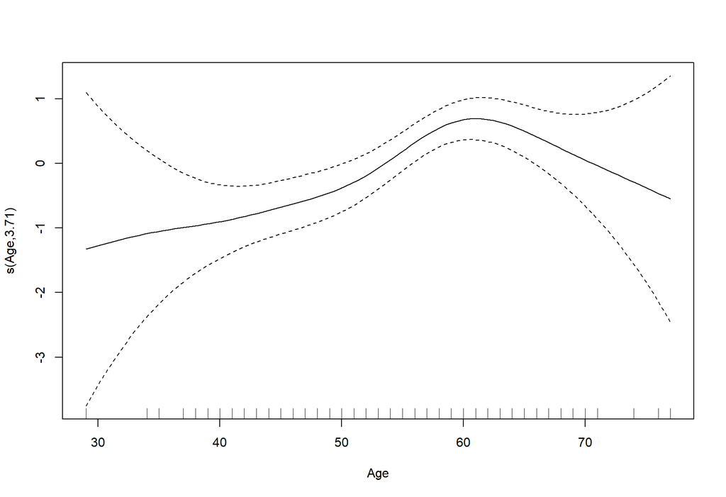

```r
heart <- read.csv("heart.csv")

# convert AHD into binary outcome
heart$AHD <- ifelse(heart$AHD == "Yes", 1, 0)

# fit gam with smoothing spline for age
gam_age <- gam(AHD ~ s(Age), data = heart, family = binomial)

# plot relationship of predictor with smoothing spline
plot(gam_age, select = 1, se = TRUE)
```

```r
# summary of model
summary(gam_age)
```

```
##
## Family: binomial
## Link function: logit
##
## Formula:
## AHD ~ s(Age)
##
## Parametric coefficients:
##             Estimate Std. Error z value Pr(>|z|)
## (Intercept)  -0.1840     0.1202   -1.53    0.126
##
## Approximate significance of smooth terms:
##          edf Ref.df Chi.sq  p-value
## s(Age) 3.713  4.674  22.92 0.000345 ***
## ---
## Signif. codes:  0 '***' 0.001 '**' 0.01 '*' 0.05 '.' 0.1 ' ' 1
##
## R-sq.(adj) =  0.076   Deviance explained = 6.47%
## UBRE = 0.32139  Scale est. = 1         n = 303
```

```r
# fit logistic regression model with 3rd degree polynomials for age
logit <- glm(AHD ~ poly(Age,3), data = heart, family = binomial)

# summary of model
summary(logit)
```

```
##
## Call:
## glm(formula = AHD ~ poly(Age, 3), family = binomial, data = heart)
##
## Deviance Residuals:
##     Min       1Q   Median       3Q      Max
## -1.3658  -1.1091  -0.7319   1.0655   1.9309
##
## Coefficients:
##               Estimate Std. Error z value Pr(>|z|)
## (Intercept)    -0.1889     0.1204  -1.568  0.11678
## poly(Age, 3)1   8.2834     2.1938   3.776  0.00016 ***
## poly(Age, 3)2  -3.7551     2.1895  -1.715  0.08633 .
## poly(Age, 3)3  -4.3864     2.2421  -1.956  0.05042 .
## ---
## Signif. codes:  0 '***' 0.001 '**' 0.01 '*' 0.05 '.' 0.1 ' ' 1
##
## (Dispersion parameter for binomial family taken to be 1)
##
##     Null deviance: 417.98  on 302  degrees of freedom
## Residual deviance: 395.10  on 299  degrees of freedom
## AIC: 403.1
##
## Number of Fisher Scoring iterations: 4
```

**Interpretation:**

The logistic regression model with third-degree polynomials calculates the coefficients for the linear, quadratic, and cubic age terms. These coefficients determine the impact of each term on the log-odds of developing heart disease. The coefficient estimates reveal a significant linear association with age, as indicated by the significant p-value (p = 0.00016) for the linear term. However, the quadratic and cubic terms do not reach statistical significance at conventional levels (p > 0.05).

## Question 3 (b)

Do the same as in (a) with the predictor Cholesterol independently of age.

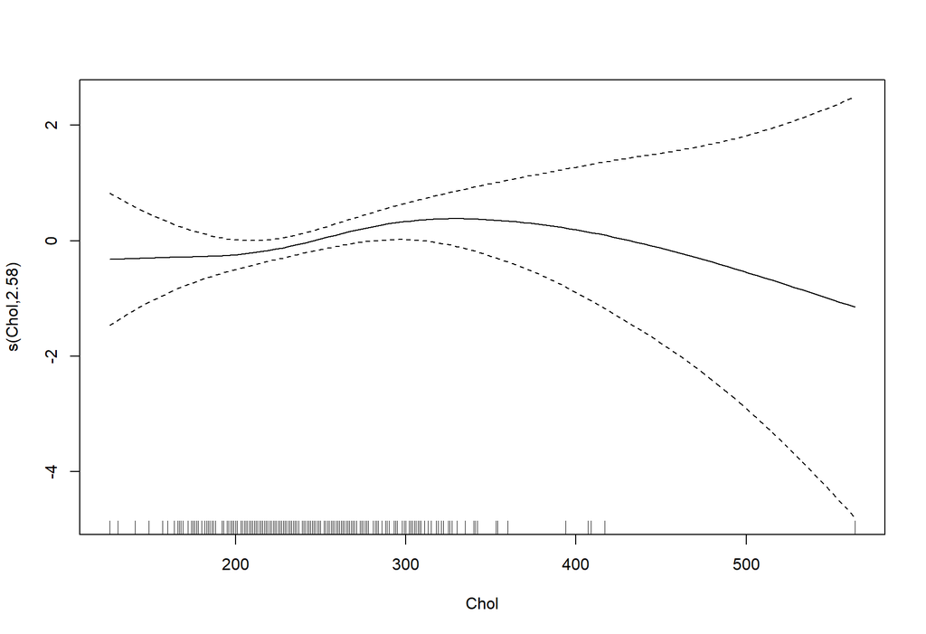

```r
# fit gam with smoothing spline for cholesterol
gam_chol <- gam(AHD ~ s(Chol), data = heart, family = binomial)

# plot relationship of predictor with smoothing spline
plot(gam_chol, select = 1, se = TRUE)
```

```r
# summary of model
summary(gam_chol)
```

```
##
## Family: binomial
## Link function: logit
##
## Formula:
## AHD ~ s(Chol)
##
## Parametric coefficients:
##             Estimate Std. Error z value Pr(>|z|)
## (Intercept)  -0.1676     0.1161  -1.444    0.149
##
## Approximate significance of smooth terms:
##           edf Ref.df Chi.sq p-value
## s(Chol) 2.585   3.33  4.575   0.212
##
## R-sq.(adj) =  0.0126   Deviance explained = 1.55%
## UBRE = 0.38178  Scale est. = 1         n = 303
```

## Question 3 (c)

With the chosen smoothing parameter in (a) and (b), fit two models - one with a smoothing spline of age only and another with smoothing splines of age and cholesterol. Compare the two models statistically with an Chi-square test.

```r
# fit gam with smoothing splines for age and chol
gam_age_chol <- gam(AHD ~ s(Age) + s(Chol), data = heart, family = binomial)

# Chi-square test comparing the two models
anova(gam_age, gam_age_chol, test = "Chisq")
```

```
## Analysis of Deviance Table
##
## Model 1: AHD ~ s(Age)
## Model 2: AHD ~ s(Age) + s(Chol)
##   Resid. Df Resid. Dev     Df Deviance Pr(>Chi)
## 1    297.33     390.95
## 2    293.76     385.74 3.5656   5.2109   0.2162
```